# 431 Class 02

## In which year did I look oldest?

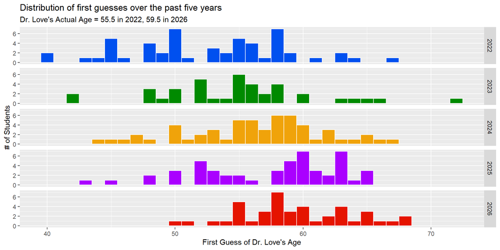

## Same plot with binwidth doubled

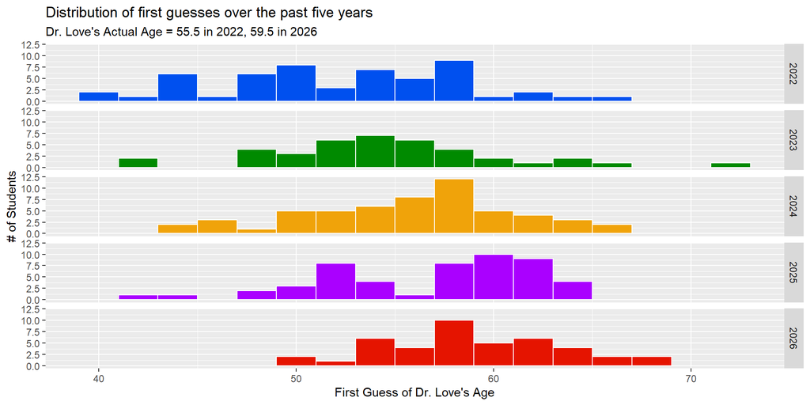

## Comparison Boxplot (w/violins)

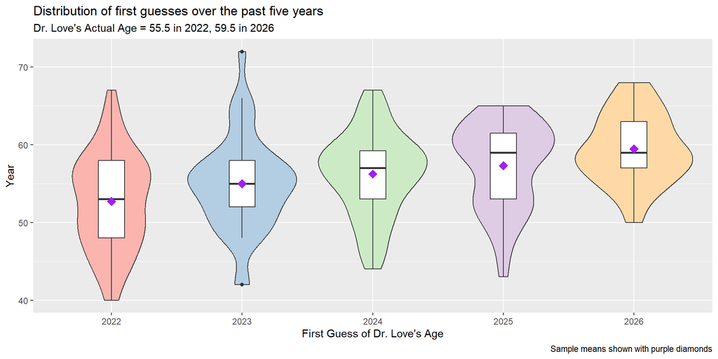

## Histogram of Guess Changes

What will this look like?

```r
age_guess <- age_guess |> mutate(change = guess2 - guess1)

ggplot(data = age_guess, aes(x = change)) +
  geom_histogram(binwidth = 1, fill = "royalblue", col = "white") +
  labs(x = "Change from first to second guess",
       y = "Students in 431 for Fall 2022-2026",
       title = "Most stayed close to their first guess.") +
  theme_light()
```

## Histogram of Guess Changes

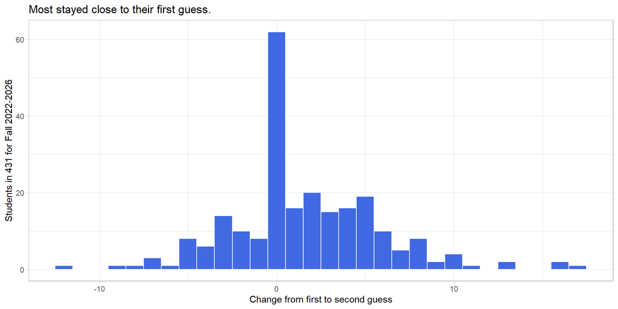

## Guess 1 vs. Guess 2 Scatterplot

```r
ggplot(data = age_guess, aes(x = guess1, y = guess2)) +
  geom_point()
```

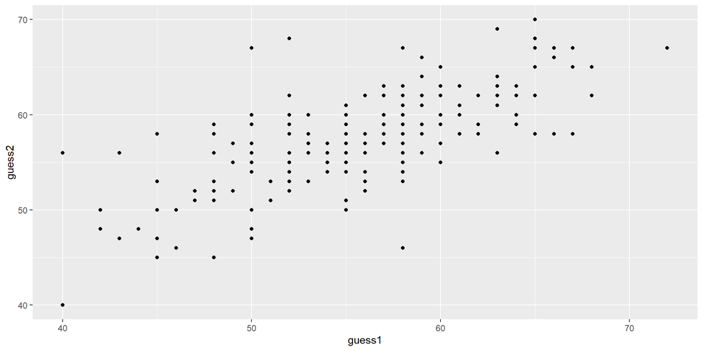

## Filter to complete cases, and add loess smooth

```r
temp <- age_guess |>
  filter(complete.cases(guess1, guess2))

ggplot(data = temp, aes(x = guess1, y = guess2)) +
  geom_point() +
  geom_smooth(method = "loess", formula = y ~ x, col = "blue")
```

## Filter to complete cases, and add loess smooth

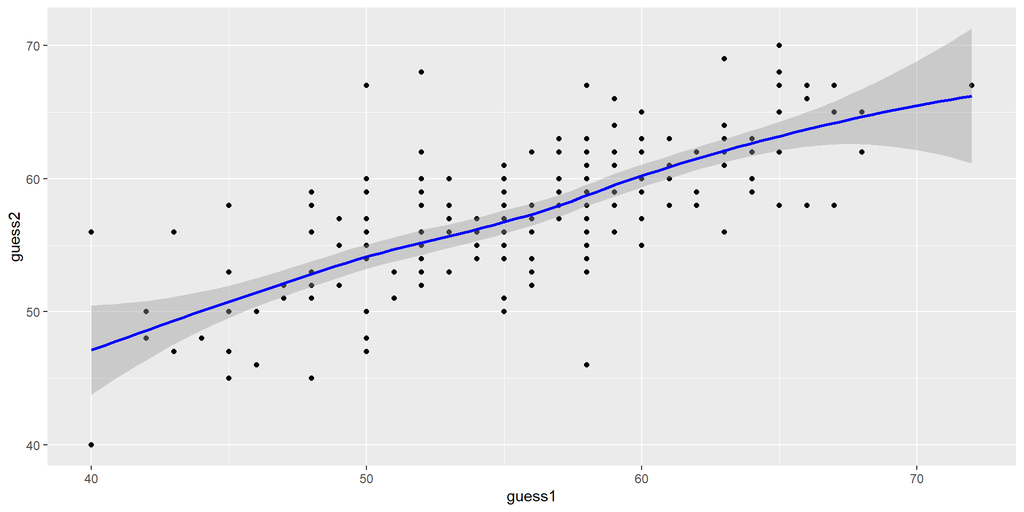

## Remove range around smooth; add regression line

```r
ggplot(data = temp, aes(x = guess1, y = guess2)) +
  geom_point() +
  geom_smooth(method = "loess", formula = y ~ x, se = FALSE, col = "blue") +
  geom_smooth(method = "lm", formula = y ~ x, col = "red")
```

## Remove range around smooth; add regression line

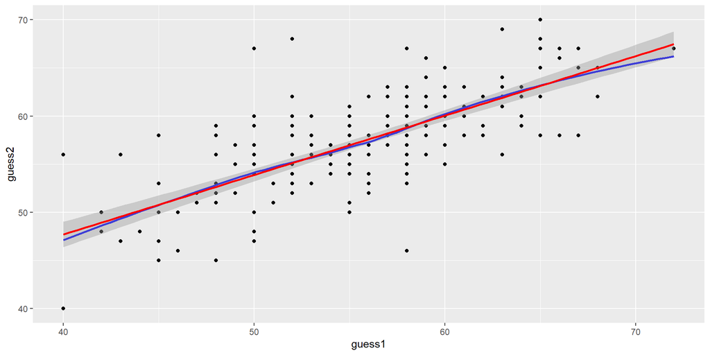

## What is that regression line?

```r
fit1 <- lm(guess2 ~ guess1, data = age_guess)
fit1
```

```
Call:
lm(formula = guess2 ~ guess1, data = age_guess)

Coefficients:
(Intercept)       guess1
    23.0136       0.6173
```

```r
model_parameters(fit1)
```

```
Parameter   | Coefficient |   SE |         95% CI | t(234) |      p
-------------------------------------------------------------------
(Intercept) |       23.01 | 2.20 | [18.67, 27.35] |  10.45 | < .001
guess1      |        0.62 | 0.04 | [ 0.54,  0.69] |  15.78 | < .001
```

By default, `lm` filters to complete cases.

## Bayesian linear regression instead?

Here, we’ll use the default set of *weakly informative* priors for these coefficients, which will likely yield a model very similar to what `lm` produced<sup>1</sup>.

```r
set.seed(431)
fit2 <- stan_glm(guess2 ~ guess1, data = age_guess, refresh = 0)
model_parameters(fit2)
```

```
Parameter   | Median |         95% CI |   pd |  Rhat | ESS (tail) |                   Prior
-------------------------------------------------------------------------------------------
(Intercept) |  23.02 | [18.80, 27.45] | 100% | 1.001 |       2668 | Normal (57.58 +- 12.87)
guess1      |   0.62 | [ 0.54,  0.69] | 100% | 1.001 |       2517 |   Normal (0.00 +- 2.15)
```

Recall the `lm` model equation: **guess2 = 23.01 + 0.62 guess1**.

[^1]: If you have no idea what I’m talking about, we’ll get there in a few weeks.

## 2026: 1st vs. 2nd Guesses

```r
ggplot(data = temp |> filter(year == "2026"), aes(x = guess1, y = guess2)) +
  geom_point() +
  geom_smooth(method = "loess", formula = y ~ x, se = FALSE, col = "blue") +
  geom_label(x = 51.5, y = 53.5, label = "loess smooth", col = "blue") +
  geom_smooth(method = "lm", formula = y ~ x, se = FALSE, col = "red") +
  geom_label(x = 52, y = 57.5, label = "lm fit", col = "red") +
  geom_abline(intercept = 0, slope = 1, col = "black") +
  geom_label(x = 53, y = 52, label = "y = x", col = "black") +
  geom_vline(xintercept = 59.5, col = "slateblue", lty = "dashed") +
  geom_label(x = 59.5, y = 54, label = "59.5", col = "slateblue") +
  labs(x = "First Guess of Love's Age",
       y = "Second Guess of Love's Age",
       title = "Student Guesses of Dr. Love's Age in 2026",
       subtitle = "Love's actual age = 59.5 in 2026")
```

Here, I’ve added a black line to indicate *y = x* (guess is the same) and labeled the three superimposed “smooths.”

## 2026: 1st vs. 2nd Guesses

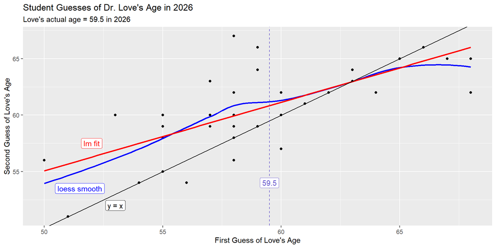